# Correlation of AQI and Weather in Los Angeles County, California

https://github.com/sarah-kear/KearLaCroix_ENV872_EDA_FinalProject

Sarah Kear and Cole LaCroix

April 30, 2024

# 1 List of Tables

- Figure 5.1: Table Dataset Structure Table
- Figure 7.1: Mann-Kendall Test Results

# 2 List of Figures

- Figure 6.1: Los Angeles County Monthly AQI from 2010 to 2022
- Figure 6.2: Los Angeles County Monthly Minimum and Maximum Temperature from 2010 to 2022
- Figure 6.3: Los Angeles County Monthly Average Wind Speed from 2010 to 2022
- Figure 6.4: Los Angeles County Monthly Precipitation from 2010 to 2022
- Figure 7.1: Los Angeles County AQI Values Time Series Decomposed Components
- Figure 7.2: Los Angeles County Daily AQI Time Series Nonseasonal Data
- Figure 7.3: Daily AQI Value Relationship with Weather Patterns

# 3 Introduction/Rationale

Air quality is a critical component of environmental health, particularly in urban settings where industrial activities, vehicular emissions, and population density contribute significantly to pollution levels. Our team studied the seasonality and correlation of daily Air Quality Index (AQI) values and their correlation with weather patterns in Los Angeles County, California. We chose Los Angeles County due to its complex history with smog, urbanization, location, and weather patterns; one of the first air pollutant stations was located in Downtown Los Angeles (South Coast Air Quality Management District, n.d).

Furthermore, daily AQI values help determine changes and trends in air quality which have direct impacts on vulnerable populations located within the County. Studies have found that higher AGI values lead to greater asthma hospitalization in Los Angeles County (Nadali et al., 2021, Neidell & Kinney, 2010). Although AQI Values are primarily used to represent air quality in a specific area, values can be impacted by local weather patterns (Di & Li, 2019, Li et al., 2019). Our study determines the seasonality of daily AQI values and their correlation with local weather patterns between January 1, 2010, and December 31, 2022.

# 4 Research Questions

1. Are the daily AQI values in Los Angeles County correlated with seasonality?
2. What is the correlations between AQI and the different weather patterns present in Los Angeles County?

# 5 Data Wrangling

The daily AQI values were pulled from the Environmental Protection Agency’s (EPA) AirNow dataset. The weather data was pulled from the National Oceanic Atmospheric Administration’s (NOAA) Climate Data Online webpage. Both datasets provided fairly complete daily data from January 1, 2010, to December 31, 2022. The datasets were cleaned and then combined to include the date of data collection and the five values used for time series analysis and generalized linear models. The five values are listed in the following table.

In our study, the measurements of air quality are quantified using the Air Quality Index (AQI), which provides a standardized framework ranging from 0 to 500, where higher values indicate poorer air quality. Temperature is reported in degrees Fahrenheit (°F). Wind speed is measured in miles per hour (MPH). Precipitation is recorded in inches (in).

Table 5.1: Table Dataset Structure Table

| Column | Description |
| --- | --- |
| Date | Date of Collection |
| Precipitation | Daily Total Precipitation |
| Temp.Max | Daily Maximum Temperature (°F) |
| Temp.Min | Daily Minimum Temperature (°F) |
| Avg.Wind | Average Wind Speed (MPH) |
| DAILY_AQI_VALUE | Daily Air Quality Index (AQI) Value |

# 6 Exploratory Analysis

Both Stations, for AQI and weather data, are located in the city center of Los Angeles County, California. We first created a map, located below, which differentiated where both stations are located within Los Angeles’ city center. We aimed for both stations to be fairly near one another so that AQI values and weather pattern data would be from the same area of the city and county.

[interactive chart not shown]

We then created graphs to illustrate the average monthly AQI values, maximum and minimum temperature, average wind speed, and precipitation. Through exploratory analysis, we found that average AQI, minimum and maximum temperature, and average wind speed slightly increased between 2010 and 2022.

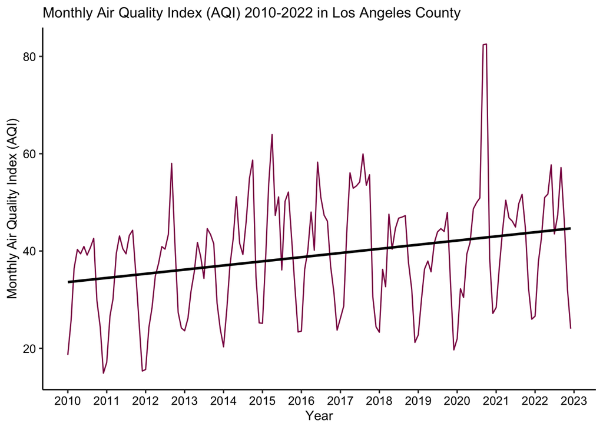

Figure 6.1: Los Angeles County Monthly AQI from 2010 to 2022

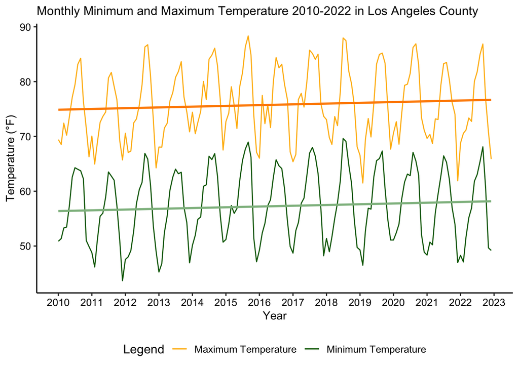

Figure 6.2: Los Angeles County Monthly Minimum and Maximum Temperature from 2010 to 2022

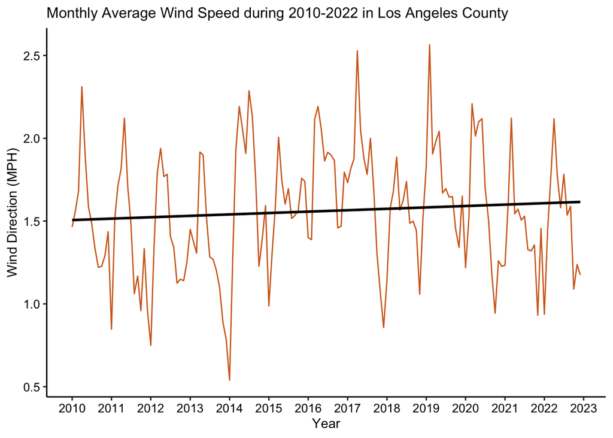

Figure 6.3: Los Angeles County Monthly Average Wind Speed

In comparison, monthly average precipitation has a slight decrease between 2010 and 2022. With the varying changes in the different weather patterns – temperature, wind speed, and precipitation – we found it critical to understand how these patterns factor into the daily AQI values.

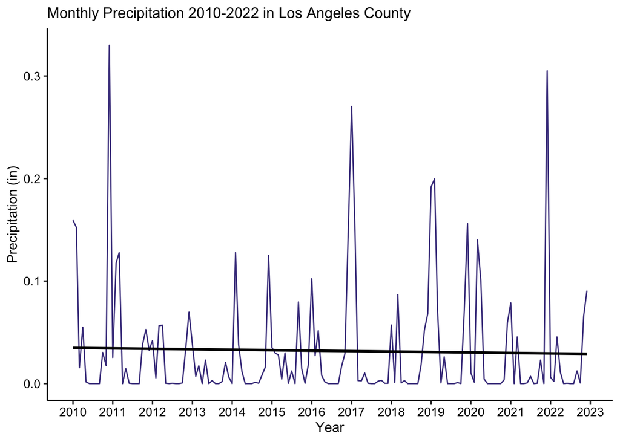

Figure 6.4: Los Angeles County Monthly Precipitation from 2010 to 2022

# 7 Analysis

Our analysis involved determining the seasonality of daily AQI values and then running a generalized linear model to determine the correlation between AQI values and determined weather patterns.

## 7.1 Time Series Analysis

To determine the effects of weather on daily AQI values, we first decomposed the daily AQI values to gather and analyze the seasonal, trend, and remainder components of the data. To conduct time series analysis on the daily AQI values, we conducted linear interpolation to fill any missing daily AQI values. We used linear interpolation as it creates an average, and best fits AQI’s daily gradual change. The following Figure illustrates the decomposed daily AQI value over time.

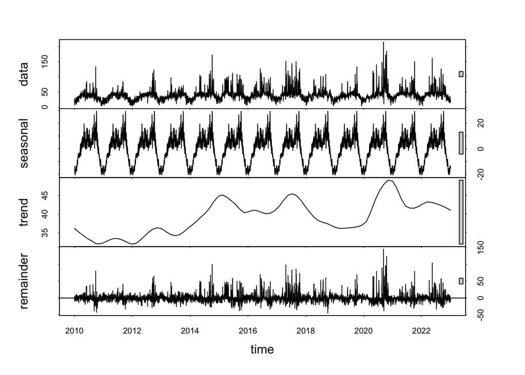

Figure 7.1: Los Angeles County AQI Values Time Series Decomposed Components

We then separated the trend and remainder data and added both together to great non-seasonal AQI values to determine how AQI value has changed throughout 2010 to 2022 without seasonality and to use when running the generalized linear models. To further analyze the non-seasonal AQI values, we reran the non-seasonal AQI values through the time series function to statistically analyze the trend, using the Mann-Kendall test. As displayed below, The p-value is less than 0.05. We can reject the null hypothesis, there is a trend present in the non-seasonal AQI values. The non-seasonal time series produces a tau value of 0.177, indicating there is an increasing trend in the non-seasonal AQI values.

Table 7.1: Mann-Kendall Test Results

| Components | Value |
| --- | --- |
| tau | 0.177 |
| 2-sided pvalue | =< 2.22e-16 |

Lastly, we plotted the non-seasonal AQI Values to illustrate the increasing trend between 2010 and 2022.

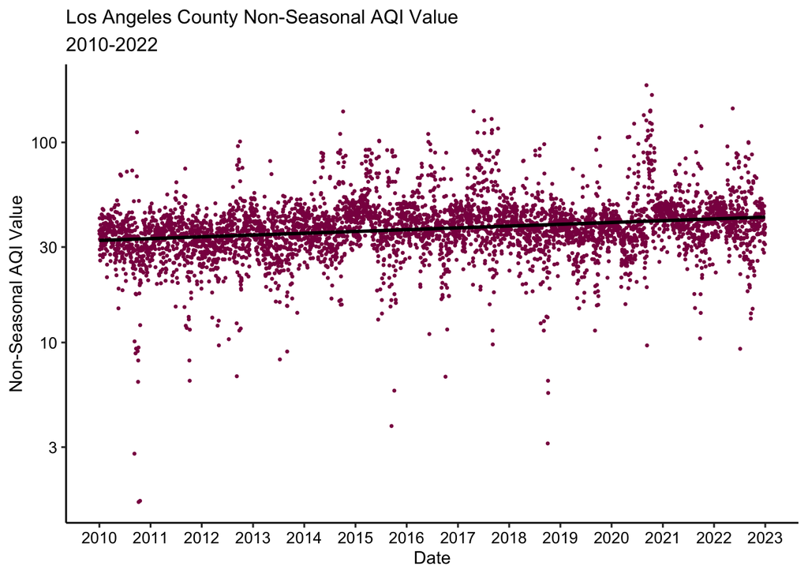

Figure 7.2: Los Angeles County Daily AQI Time Series Nonseasonal Data

## 7.2 Generalized Linear Model

The linear regression model we built to predict daily Air Quality Index (AQI) values in Los Angeles using environmental data collected from local weather stations utilized maximum temperature (Temp.Max), minimum temperature (Temp.Min), average wind speed (Avg.Wind), and precipitation levels (Precipitation) as predictors. The analysis revealed statistically significant relationships between these environmental factors and AQI values.

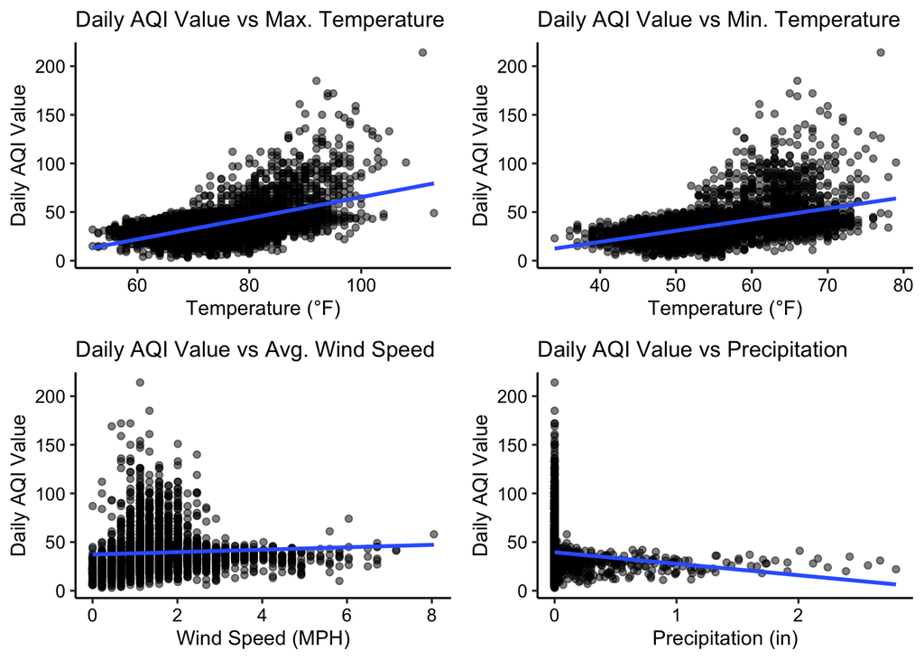

Figure 7.3: Daily AQI Value Relationship with Weather Patterns

The model’s intercept is set at -54.96859, indicating the baseline AQI value when all environmental predictors are zero. The coefficients for maximum temperature and minimum temperature were 0.99070 and 0.24680, respectively, highlighting a stronger influence of maximum temperature on AQI. Each unit increase in maximum temperature results in nearly a one-unit increase in AQI, suggesting that higher temperatures could exacerbate air pollution levels. In contrast, the coefficient for average wind speed was 3.18926, indicating a substantial increase in AQI with higher wind speeds, possibly due to the dispersion of pollutants over a larger area. Interestingly, precipitation had a negative coefficient of -2.94911, suggesting that rainfall might reduce AQI, potentially by washing out atmospheric pollutants.

|  | *Dependent variable:* |
| --- | --- |
|  | Daily AQI Value |
| Maximum Temperature (°F) | 0.991*** |
|  | (0.036) |
| Minimum Temperature (°F) | 0.247*** |
|  | (0.043) |
| Average Wind Speed (MPH) | 3.189*** |
|  | (0.264) |
| Precipitation (in) | -2.949** |
|  | (1.273) |
| Constant | -54.969*** |
|  | (1.985) |
| Observations | 4,725 |
| R<sup>2</sup> | 0.337 |
| Adjusted R<sup>2</sup> | 0.336 |
| Residual Std. Error | 14.528 (df = 4720) |
| F Statistic | 599.948*** (df = 4; 4720) |
| *Note:* | p<0.1; p<0.05; p<0.01 |

The model’s residual standard error is 14.53, reflecting the typical deviation of observed AQI values from the predicted values based on the model. With an R-squared value of 0.3371, the model explains approximately 33.71% of the variability in AQI, which is moderate, suggesting that other unaccounted factors might also influence air quality. The F-statistic of 599.9 and a p-value less than 2.2e-16 indicate a very strong overall model fit.

This model serves as a tool to understand the impact of specific meteorological conditions on air quality, which could be vital for developing strategies to manage air pollution in urban areas like Los Angeles. Further research might include additional environmental or anthropogenic factors to enhance the model’s predictive accuracy and provide a more comprehensive understanding of the factors affecting air quality.

# 8 Conclusion

In conclusion, our findings underscore the significant impact of meteorological conditions on air quality in this particular urban environment. By elucidating the roles of temperature, wind speed, and precipitation in influencing AQI, this study contributes to a more nuanced understanding of air quality dynamics in Los Angeles. The predictive model, while moderately effective, highlights the potential for integrating meteorological data into air quality management strategies to preemptively address pollution episodes. Future research should expand upon this model by incorporating other relevant variables such as traffic emissions, industrial activities, and geographic features that may also significantly affect air quality.

# 9 References

Di, Y., & Li, R. (2019). Correlation analysis of AQI characteristics and meteorological conditions in heating season. IOP Conference Series: Earth and Environmental Science, 242, 022067. https://doi.org/10.1088/1755-1315/242/2/022067

Li, Y., Zhang, J., Sailor, D. J., & Ban-Weiss, G. A. (2019). Effects of urbanization on regional meteorology and air quality in southern California. Atmospheric Chemistry and Physics, 19(7), 4439–4457. https://doi.org/10.5194/acp-19-4439-2019

Nadali, A., Leili, M., Karami, M., Bahrami, A., & Afkhami, A. (2021). The short-term association between air pollution and asthma hospitalization: A Time-series analysis. Air Quality, Atmosphere & Health, 15(7), 1153–1167. https://doi.org/10.1007/s11869-021-01111-w

National Oceanic and Atmospheric Administration.(n.d.). Climate Data Online Data Tools. https://www.ncei.noaa.gov/cdo-web/datatools

Neidell, M., & Kinney, P. L. (2010). Estimates of the association between ozone and asthma hospitalizations that account for behavioral responses to air quality information. Environmental Science & Policy, 13(2), 97–103. https://doi.org/10.1016/j.envsci.2009.12.006

South Coast Air Quality Management District. (n.d.). History of Air Pollution Control in Southern California. https://www.aqmd.gov/home/research/publications/history-of-air-pollution-control

U.S. Environmental Protection Agency. (n.d.). Download Daily Data. https://www.epa.gov/outdoor-air-quality-data/download-daily-data.